Just like ecosystems on land, our rocky shores are sensitive to invasive species from other parts of the world. Invasive algae like Sargassum can out-compete native algae and alter the entire ecosystem.

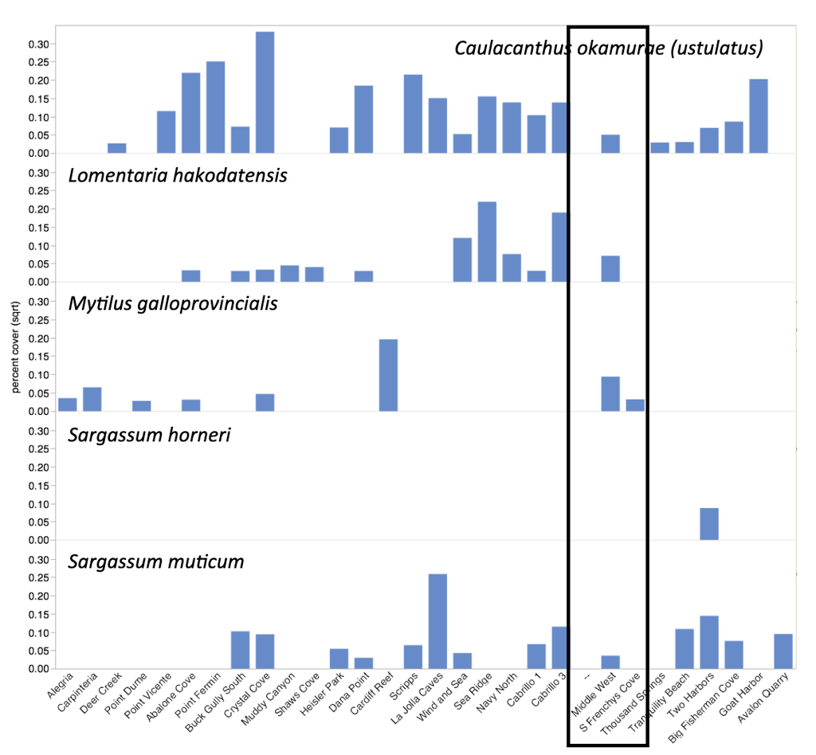

A figure showing the amount of non-native invertebrates and algae foundin rocky intertidal sites in Southern California; the two sites in Channel Islands National Marine Sanctuary are highlighted by the black box. Figure credit: Blanchette et al. 2015.

**Click for Details**

Percent cover of non-indigenous taxa in [PISCO](http://www.piscoweb.org/) biodiversity surveys at rocky intertidal sites in southern California; the two sites in Channel Islands National Marine Sanctuary are highlighted by the black box. PISCO found the turfy red alga *Caulacanthus okamurae* (formerly *C. ustulatus*), *Lomentaria hakodatensis*, and the brown algae *Sargassum muticum* at Middle West on Anacapa Island. The mussel *Mytilus galloprovincialis* was found at two sites on Anacapa Island. Additionally, the report noted that *Annalipus japonicus*, a brown alga, was found at Crook Point (San Miguel Island) south of its published southern range limit of Point Conception. Shallow subtidal *Sargassum muticum* was densely abundant in many areas in 1970s and 1980s, but has become relatively less common and more interspersed with native species in recent years (J. Engle, pers. comm.). For more information, consult Figure App.F.14.1 in the CINMS 2016 Condition Report. For more information, consult Figure App.F.14.1 in the [CINMS 2016 Condition Report](https://nmssanctuaries.blob.core.windows.net/sanctuaries-prod/media/docs/2016-condition-report-channel-islands-nms.pdf).